# ATACseq

Tim Stuart

29/10/2016

# ATAC salt stress

## Distribution of reads

```r
library(readr)
library(dplyr)
```

```r
library(RColorBrewer)
library(ggplot2)
```

Load data

```r
files <- list.files("../Data/read_counts/", full.names = TRUE)
dat <- lapply(files, read_tsv)
names(dat) <- list.files("../Data/read_counts/")
```

Define function

```r
plot_heatmap <- function(d, chromosome, color, sample_name, max_value) {
        subs_data <- d[d$chromosome == chromosome,]
        scaled_data <- scale_max(as.matrix(subs_data$rpkm), max_value)
        return(image(scaled_data,
                     col = color,
                     main = sample_name,
                     xaxt="n", yaxt="n"))
}

scale_max <- function(m, l){
  m.floor <- m > l
  m[m.floor] <- l
  return(m)
}

get_max <- function(d, chromosome){
        subs_data <- d[d$chromosome == chromosome,]
        return(max(subs_data$rpkm))
}
```

```r
color <- colorRampPalette(brewer.pal(9, "YlGn"))(100)
```

There is a problem with chromosome 2, extremely high counts draws the whole thing up

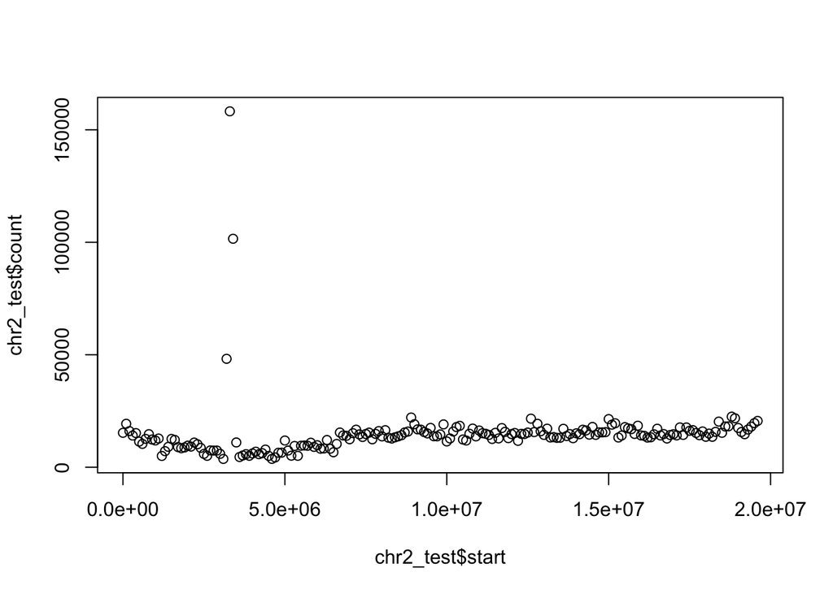

```r
chr2_test <- filter(dat[[1]], chromosome == '2')
plot(chr2_test$count ~ chr2_test$start)
```

We need to omit these three points in all the samples.

Easiest way to locate them is to filter where count > 40000

```r
filter(chr2_test, count > 40000) %>% knitr::kable()
```

| chromosome | start | stop | coverage | normalized_coverage | count | rpkm |
| --- | --- | --- | --- | --- | --- | --- |
| 2 | 3200000 | 3300000 | 24.27316 | 8.363134 | 48207 | 16609.36 |
| 2 | 3300000 | 3400000 | 79.63553 | 27.437820 | 158208 | 54509.37 |
| 2 | 3400000 | 3500000 | 51.20090 | 17.640883 | 101569 | 34994.83 |

So we want to remove points on chromosome 2 where position between 3200000 and 3500000 for all samples

```r
filter_region <- function(df, chromosome, start, stop){
        area_mask <- df$chromosome == chromosome & df$start >= start & df$stop <= stop
        df[area_mask,c("coverage","normalized_coverage", "count", "rpkm")] <- NA
        return(df)
}
```

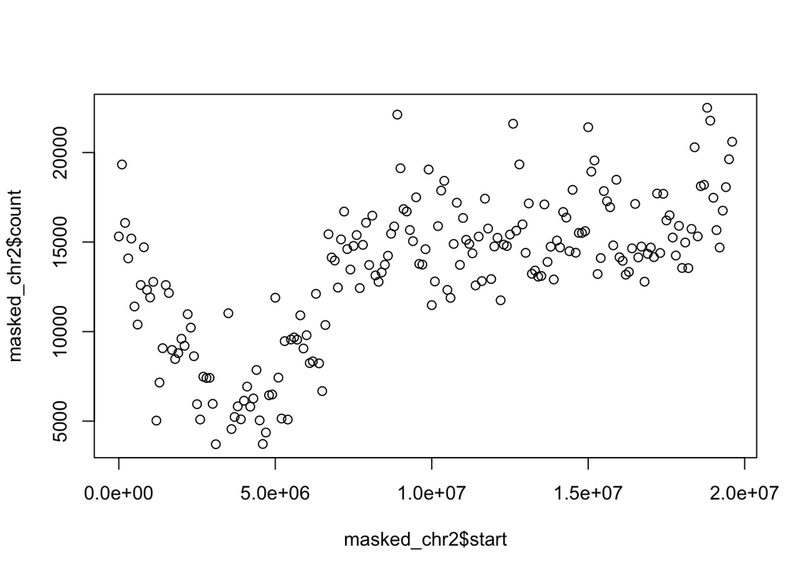

```r
masked_chr2 <- filter_region(chr2_test, "2", 3200000, 3500000)
plot(masked_chr2$count ~ masked_chr2$start)
```

Apply to each sample

```r
dat <- lapply(dat, filter_region, chromosome="2", start=3200000, stop=3500000)
```

Make a vector that contains the maximal value to set for each chromosome

Find the maximum value to set for each chromosome (smallest maximum value among the samples)

```r
all_data <- data_frame(chromosome = c("1", "2", "3", "4", "5", "Mt", "Pt"))
for(i in seq_along(dat)) {
        temp <- dat[[i]] %>%
                group_by(chromosome) %>%
                summarise(highest = max(rpkm, na.rm = TRUE))
        all_data <- cbind(all_data, temp$highest)
}
minimums <- by(all_data, 1:nrow(all_data), function(row) min(row[2:length(row)]))
```

```r
image_maxima <- c(minimums[[1]], minimums[[2]], minimums[[3]],
                  minimums[[4]], minimums[[5]])
image_maxima <- lapply(image_maxima, round, digits=-2)
names(image_maxima) <- c("1", "2", "3", "4", "5")
```

Save that scale info for future reference

```r
write_tsv(as_data_frame(image_maxima), path = "../Data/scales.tsv")
```

Apply function to list of files

```r
for(chrom in seq(1, 5)){
        pdf(paste("../Plots/chr", as.character(chrom), ".pdf", sep = ""), height = 35, width = 5)
        par(mfrow=c(23, 1))
        for(i in seq_along(dat)){
                plot_heatmap(dat[[i]], chromosome = as.character(chrom),
                             color = color,
                             sample_name = unlist(strsplit(names(dat[i]), ".", fixed = TRUE))[[1]],
                             max_value = image_maxima[chrom][[1]])
        }
        dev.off()
}
pdf("../Plots/scale_bar.pdf", height = 2, width = 5)
image(matrix(seq(100)), col = color, main = "scale")
dev.off()
```

## Ratio of reads in pericentromeres to chromosome arms

Load centromere positions data

```r
centromeres <- read_tsv("../Data/centromeres.txt", col_names = c("chromosome", "start", "stop"))
```

Need to add a column to each dataframe with the distance to the nearest centromere

```r
get_centro_distance <- function(chrom, start, stop, centromeres) {
  cent <- centromeres[centromeres$chromosome == as.numeric(chrom),]
  midpoint <- (cent[[3]] + cent[[2]]) / 2
  start_d <- abs(as.numeric(start) - midpoint)
  stop_d <- abs(as.numeric(stop) - midpoint)
  return(min(start_d, stop_d))
}

for(i in seq_along(dat)) {
        dat[[i]] <- dat[[i]] %>%
                filter(chromosome %in% c("1", "2", "3", "4", "5")) %>%
                rowwise() %>%
                mutate(centromere_distance = get_centro_distance(chromosome, start, stop, centromeres)) %>%
                mutate(centromeric = centromere_distance < 3*10^6)
}
```

Try a boxplot of read counts in the 100 kb bins in arms vs centromeric regions

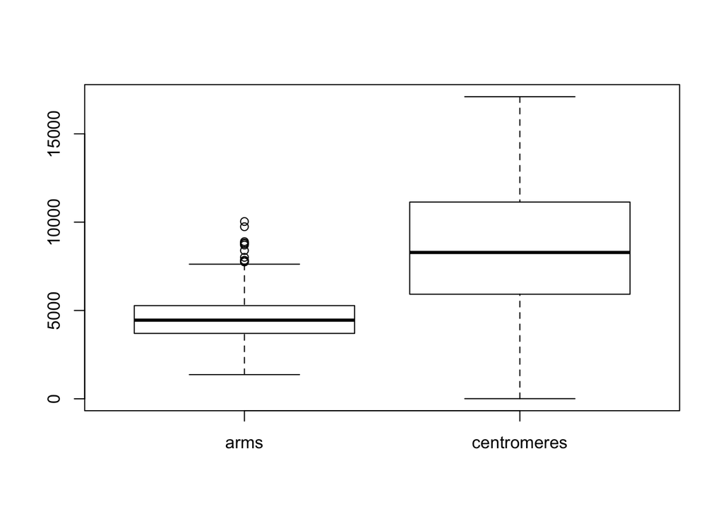

```r
arms <- filter(dat[[1]], centromeric == FALSE)
centro <- filter(dat[[1]], centromeric == TRUE)
boxplot(arms$rpkm, centro$count, names = c("arms", "centromeres"))
```

Apply to all samples

```r
# construct a dataframe
boxplot_data <- data_frame(sample = factor(), rpkm = double(), centromeric = logical())
for(i in seq_along(dat)) {
        sample_name <- unlist(strsplit(names(dat[i]), ".", fixed = TRUE))[1]
        df <- dat[[i]]
        centro <- filter(df, centromeric == TRUE) %>% select(rpkm, centromeric)
        arms <- filter(df, centromeric == FALSE) %>% select(rpkm, centromeric)
        new_df <- rbind(centro, arms)
        new_df$sample <- sample_name
        boxplot_data <- rbind(boxplot_data, new_df)
}
```

Plot boxplots

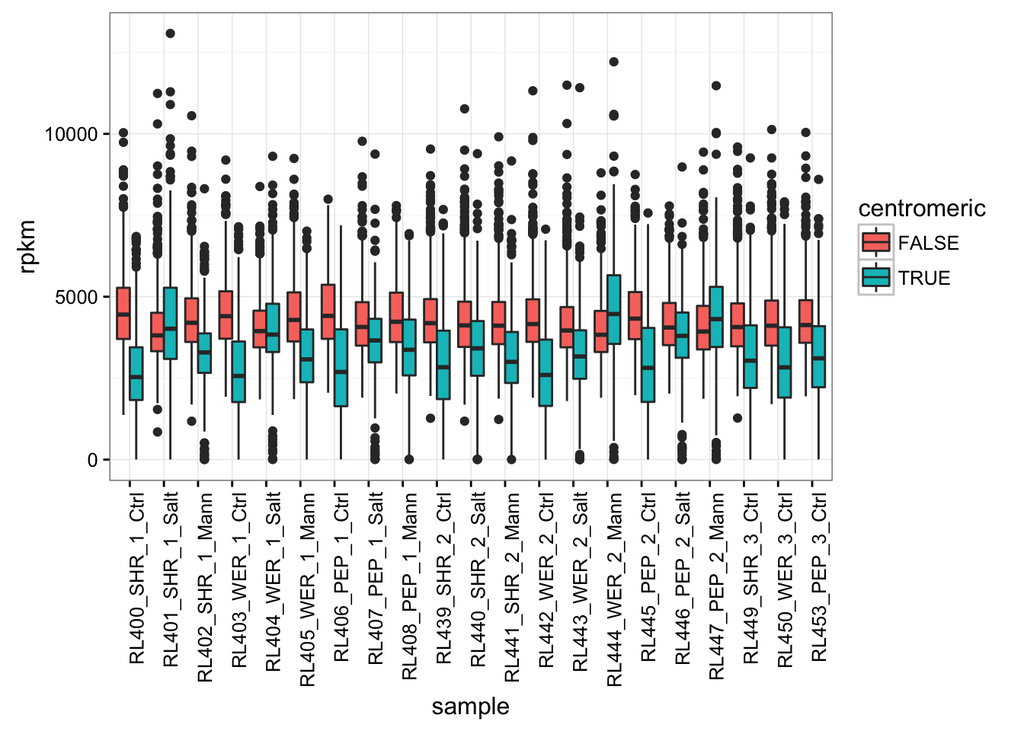

```r
ggplot(boxplot_data, aes(sample, rpkm, fill = centromeric)) +
        geom_boxplot() +
        theme_bw() +
        theme(axis.text.x = element_text(angle = 90, hjust = 1))
```

Group by treatment

```r
library(tidyr)
```

```r
boxplot_data <- boxplot_data %>%
        separate(sample, c("ID", "Cell", "replicate", "Treatment")) %>%
        unite(cell, Cell, replicate, sep = "_")
```

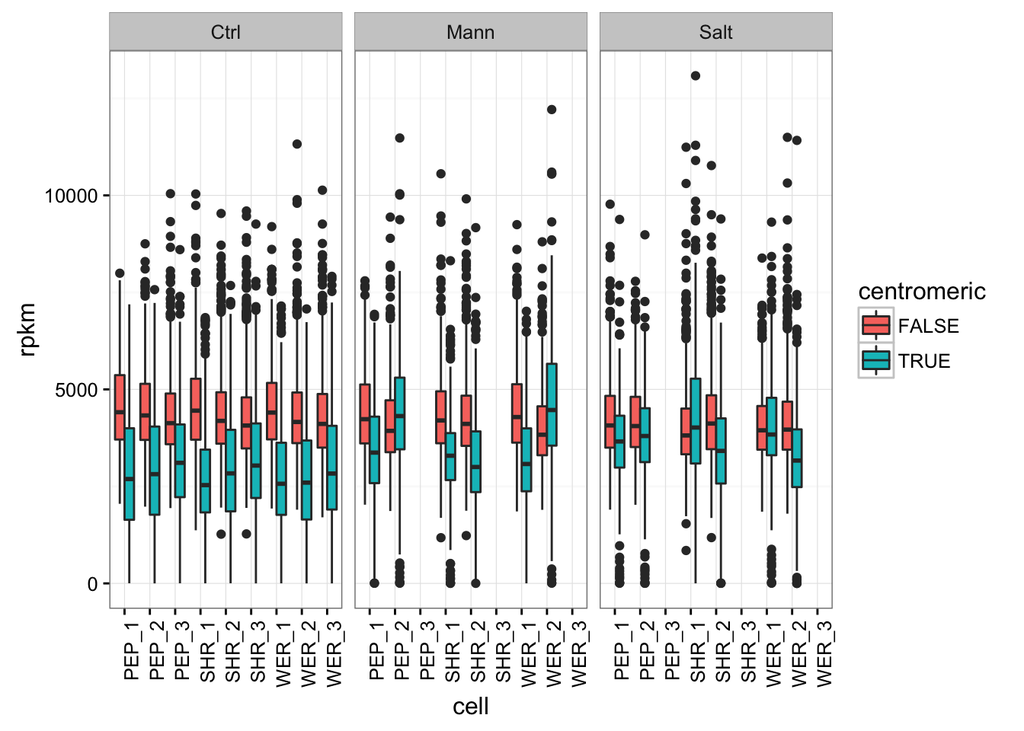

```r
p <- ggplot(boxplot_data, aes(cell, rpkm, fill = centromeric)) +
        geom_boxplot() +
        facet_wrap(~Treatment) +
        theme_bw() +
        theme(axis.text.x = element_text(angle = 90, hjust = 1))
p
```

Save plot

```r
ggsave(p, filename = "../Plots/boxplot.pdf", height = 5, width = 15)
```

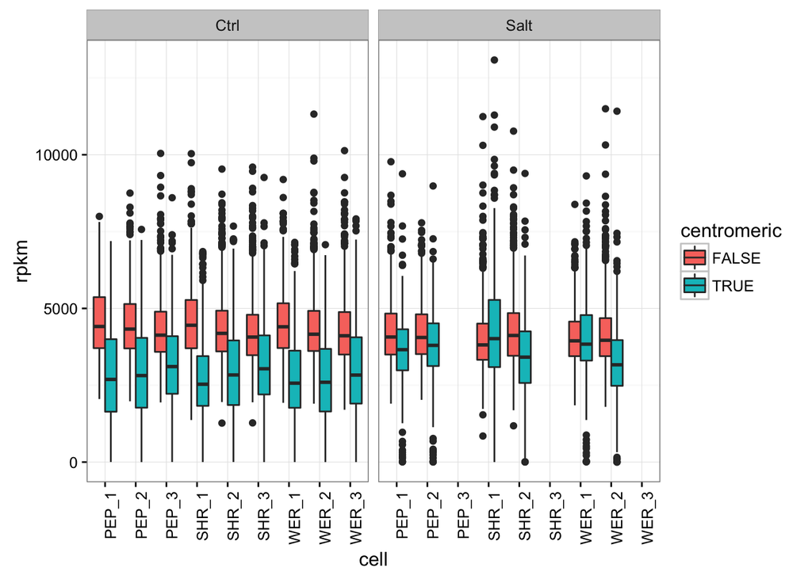

```r
p <- boxplot_data %>%
        filter(Treatment != "Mann") %>%
        ggplot(., aes(cell, rpkm, fill = centromeric)) +
                geom_boxplot() +
                facet_wrap(~Treatment) +
                theme_bw() +
                theme(axis.text.x = element_text(angle = 90, hjust = 1))
p
```

```r
ggsave(p, filename = "../Plots/reduced_boxplot.pdf", height = 5, width = 10)
means <- boxplot_data %>%
        group_by(cell, Treatment, centromeric) %>%
        summarise(av = mean(rpkm, na.rm = TRUE))
write_tsv(means, path = "../Data/mean_rpkm.tsv")
```